# Egarch模型预测

2020/5/19

## 3.Egarch模型预测

**3.1 rugarch包介绍**

- 该模型由三个部分构成，均值方程对应式（1），分布假设对应（2），方差方程对应式（3），对三个部分进行适当的变形后可以形成egarch模型，egarch-ged模型，egarch-t模型，Igarch模型，garch-m模型和Qgarch模型等。因此，设定模型形式就是分别设定均值方程、方差方程和分布。
- ugarch包的优越之处正在于这里。ugarchspec函数的参数也被分解为为三个主要部分，分别是variance.model，对应式（3），mean.model，对应式（1），distribution.model对应式（2）中的\(\epsilon\)。通过对三个部分的参数的分别设定从而构造出自己想用的模型。

\(r_{t}=c_1+\sum_{i=1}^{R}\phi_{i}r_{t-i}+\sum_{j=1}^{M}\phi_{j}ϵ_{t-j}+ϵ_{t}\)(1)

\(ϵ_{t}=\mu_{t}\sqrt{h_{t}}\)(2)

\(h_{t}=k+\sum_{i=1}^{q}G_{i}h_{t-i}+\sum_{i=1}^{p}A_{i}{ϵ_{t-i}}^2\)(3)

**3.2 预测过程**

- 载入包

```r
library (fBasics)
library (rugarch)#garch拟合与预测
library (forecast)#auto.arima() arma阶数确定方法
library (ggplot2)#绘图
```

**3.2预测过程**

- 载入数据

```r
setwd ("C:/Users/10982/E-GARCH.again/data")
HS <- read.csv ("HS300.csv")
##计算对数收益率
dHS <- diff (log(HS$CLOSE))
head (dHS)
```

```
## [1]  0.020565751 -0.004297836  0.012178686 -0.007050487 -0.005779561
## [6]  0.030194063
```

- 2016年2月4日-2020年5月15日沪深300指数为数据，一共有1042个数据。

**3.2预测过程**

- ARMA定阶

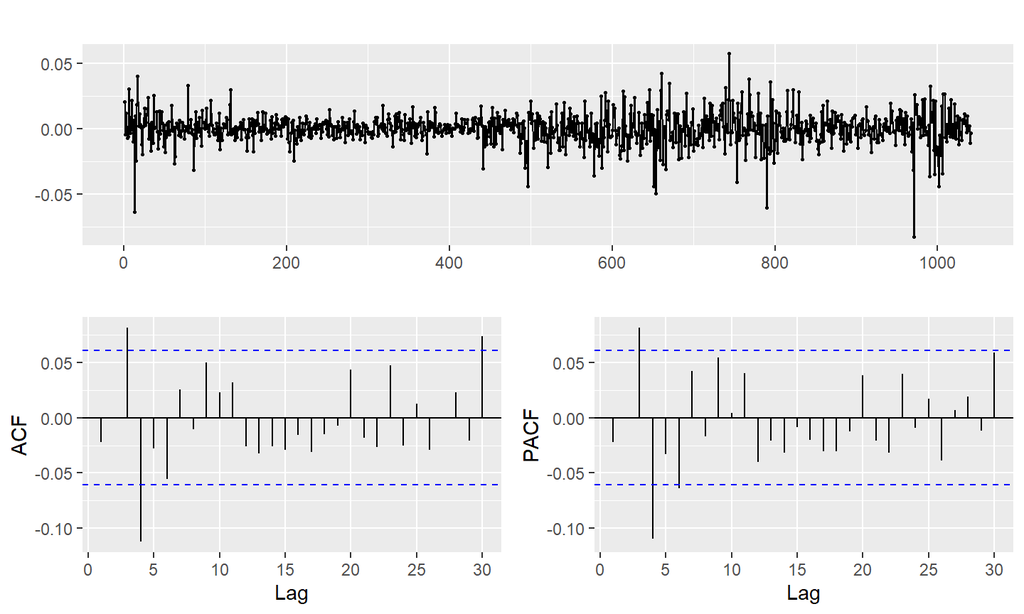

```r
forecast::ggtsdisplay (dHS)
```

**3.2预测过程**

- 建模

```r
myspec = ugarchspec(
  variance.model = list(model = "eGARCH", garchOrder = c(1, 1)),
  mean.model = list(armaOrder = c(4,4), include.mean = TRUE),
  distribution.model = "std"
)
myfit = ugarchfit ( myspec, data=dHS, solver = "gosolnp" )
myfit
```

```
##
## *---------------------------------*
## *          GARCH Model Fit        *
## *---------------------------------*
##
## Conditional Variance Dynamics
## -----------------------------------
## GARCH Model  : eGARCH(1,1)
## Mean Model   : ARFIMA(4,0,4)
## Distribution : std
##
## Optimal Parameters
## ------------------------------------
##         Estimate  Std. Error   t value Pr(>|t|)
## mu      0.000617    0.000229   2.69311 0.007079
## ar1     0.494914    0.078800   6.28064 0.000000
## ar2     0.405887    0.030820  13.16964 0.000000
## ar3    -0.579430    0.042742 -13.55656 0.000000
## ar4    -0.184172    0.058777  -3.13339 0.001728
## ma1    -0.522070    0.071237  -7.32862 0.000000
## ma2    -0.406859    0.058717  -6.92917 0.000000
## ma3     0.617263    0.042818  14.41596 0.000000
## ma4     0.082095    0.072894   1.12623 0.260070
## omega  -0.123262    0.016227  -7.59598 0.000000
## alpha1 -0.015958    0.018565  -0.85957 0.390026
## beta1   0.986619    0.001822 541.62656 0.000000
## gamma1  0.138234    0.038470   3.59331 0.000327
## shape   4.467965    0.644674   6.93058 0.000000
##
## Robust Standard Errors:
##         Estimate  Std. Error   t value Pr(>|t|)
## mu      0.000617    0.000261   2.36768 0.017900
## ar1     0.494914    0.039180  12.63195 0.000000
## ar2     0.405887    0.098572   4.11767 0.000038
## ar3    -0.579430    0.026045 -22.24759 0.000000
## ar4    -0.184172    0.075827  -2.42884 0.015147
## ma1    -0.522070    0.045916 -11.37001 0.000000
## ma2    -0.406859    0.110868  -3.66975 0.000243
## ma3     0.617263    0.021965  28.10234 0.000000
## ma4     0.082095    0.084273   0.97415 0.329980
```

[output cut: 67 more lines]

```
## Negative Sign Bias  2.1702 0.03022  **
## Positive Sign Bias  0.4229 0.67247
## Joint Effect        5.0170 0.17055
##
##
## Adjusted Pearson Goodness-of-Fit Test:
## ------------------------------------
##   group statistic p-value(g-1)
## 1    20     17.12       0.5819
## 2    30     18.63       0.9305
## 3    40     30.09       0.8465
## 4    50     33.02       0.9612
##
##
## Elapsed time : 7.149146
```

**3.2预测过程**

- 建模

```r
myspec = ugarchspec(
  variance.model = list(model = "eGARCH", garchOrder = c(1, 1)),
  mean.model = list(armaOrder = c(4,4), include.mean = TRUE),
  distribution.model = "std"
)
myfit = ugarchfit ( myspec, data=dHS, solver = "gosolnp" )
myfit
```

[output not shown]

- model 是一个字符串，指定拟合哪种类型的 GARCH 模型。包支持许多主要的 GARCH 模型（例如 EGARCH、IGARCH 等），对于“普通”GARCH 模型，要将其设置为 sGARCH（或者只是忽略它，标准模型是默认的)，此处设置为为 EGARCH。 garchOrder 是模型中 ARCH 和 GARCH 部分的阶数向量。
- mean.model 允许拟合 ARMA-GARCH 模型，并且像 variance.model 一样接受一个命名列表，最感兴趣的参数是 armaOrder 和 include.mean。armaOrder 就像 garchOrder，它是一个指定 ARMA 模型阶数的向量。include.mean 是一个布尔值，如果为 true，则允许模型的 ARMA 部分具有非零均值。

**3.3预测结果**

```r
 forc = ugarchforecast ( myfit, n.ahead = 20)
forc
```

```
##
## *------------------------------------*
## *       GARCH Model Forecast         *
## *------------------------------------*
## Model: eGARCH
## Horizon: 20
## Roll Steps: 0
## Out of Sample: 0
##
## 0-roll forecast [T0=1972-11-07 08:00:00]:
##          Series   Sigma
## T+1   1.441e-03 0.01004
## T+2   1.378e-03 0.01004
## T+3   1.893e-03 0.01004
## T+4   1.394e-03 0.01004
## T+5   9.266e-04 0.01004
## T+6   2.059e-04 0.01004
## T+7  -1.462e-04 0.01004
## T+8  -2.503e-04 0.01004
## T+9   5.898e-05 0.01004
## T+10  5.066e-04 0.01004
## T+11  9.787e-04 0.01004
## T+12  1.234e-03 0.01004
## T+13  1.236e-03 0.01004
## T+14  9.843e-04 0.01004
## T+15  6.256e-04 0.01004
## T+16  2.979e-04 0.01003
## T+17  1.356e-04 0.01003
## T+18  1.765e-04 0.01003
## T+19  3.867e-04 0.01003
## T+20  6.617e-04 0.01003
```

**3.3预测结果**

- 数据还原
- 数据建模之前进行平稳化化处理，去除了趋势（差分取对数），因此对数据还原，方便观察。

```r
 t = forc@forecast [["seriesFor"]]
 m = HS$CLOSE [1042]
  x=t
  x[1] = m + exp(t[1])
 for (i in 2:20) {
    x[i] = x[i-1]+ exp(t[i])
 }
date = c("2020/5/16", "2020/5/17", "2020/5/18","2020/5/19", "2020/5/20", "2020/5/21", "2020/5/22", "2020/5/23", "2020/5/24", "2020/5/25", "2020/5/26", "2020/5/27", "2020/5/28", "2020/5/29", "2020/5/30", "2020/5/31", "2020/6/1", "2020/6/2", "2020/6/3", "2020/6/4")
xx = data.frame (date,x)
names (xx) = c("DATE","CLOSE")
xl = rbind(HS,xx)
```

**3.3预测结果**

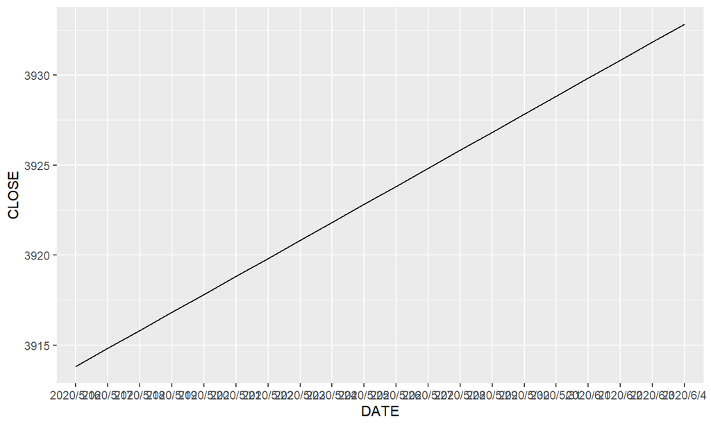

```r
ggplot (xx, mapping = aes (x = DATE , y = CLOSE, group=1))+ geom_line()
```

**3.3预测结果**

- 时序图

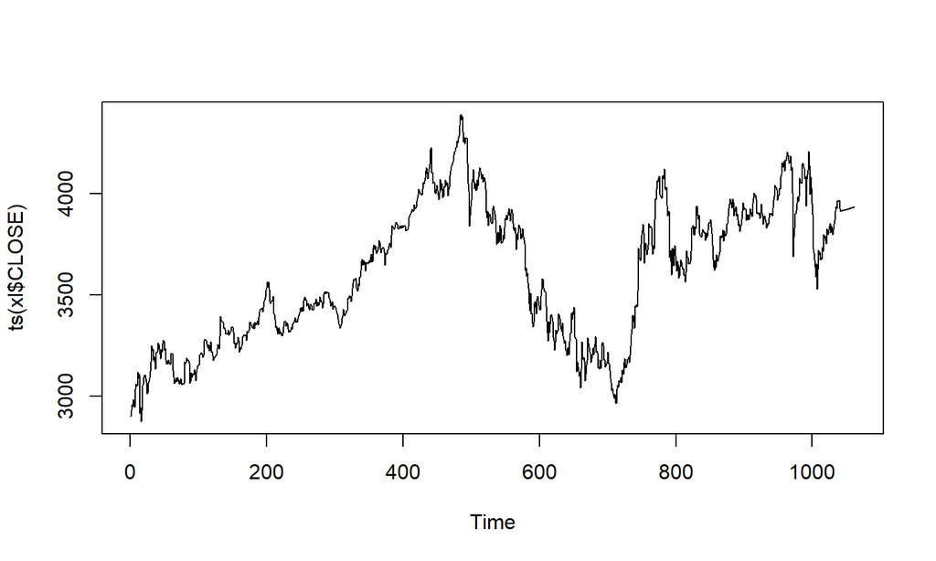

```r
plot (ts ( xl$CLOSE))
```